# Ivy League Exam Analysis

Bugame Gift

# 1 .Introduction

Analysis of the Ivy League Exam done by Standard 8 pupils at Ebulako Primary School in 2023. The students are divided into 3 streams namely **Atlanta**, **Indianna** and **Pacifica**. Each of the students sat 5 exams for the 5 compulsory subjects offered at the Primary school level. They are English, Kiswahili, Mathematics, Science and SSRE. (*Social Studies and Religious Education*) Each subject is marked out of 100 marks, therefore the maximum total mark a student can attain is 500 marks. A total of 179 students sat the exam and had their marks recorded and analysed below.

# 2. Class performance per subject

## a. English

Here are the descriptive summaries of how students from Atlanta performed in English.

|  | 25% |
| --- | --- |
| **minimum** | 8 |
| **lower.quartile** | 43.75 |
| **Median** | 55 |
| **upper.quartile** | 64 |
| **maximum** | 78 |
| **average** | 53.45 |
| **standard.deviation** | 14.38 |
| **c.o.v** | 26.91 |

### Distribution

The table below shows the percentage distribution of marks in English.

| 0-10 | 11-20 | 21-30 | 31-40 | 41-50 | 51-60 | 61-70 | 71-80 | 81-90 | 91-100 |
| --- | --- | --- | --- | --- | --- | --- | --- | --- | --- |
| 2 | 0 | 4 | 15 | 22 | 24 | 24 | 12 | 0 | 0 |

A majority of the students in Atlanta attained a score ranging from 51 to 70.

### Density function

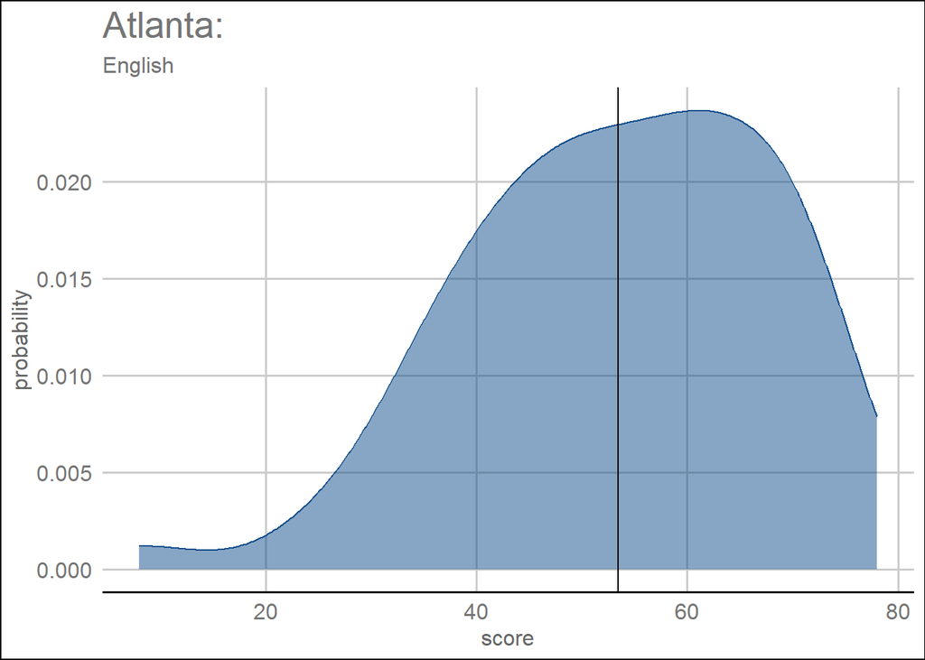

Atlanta’s English scores have a kurtosis value of 3.19 and a skewness value of -0.59. This implies that the distribution is *leptokurtic* and is *skewed negatively* about the mean.

## b. Kiswahili

Here are the descriptive summaries of how students from Atlanta performed in Kiswahili.

|  | 25% |
| --- | --- |
| **minimum** | 30 |
| **lower.q** | 53.75 |
| **Median** | 63 |
| **upper.q** | 70.25 |
| **maximum** | 83 |
| **average** | 61.07 |
| **standard.dev** | 13.03 |
| **c.o.v** | 21.34 |

### Distribution

The table below shows the percentage distribution of marks in Kiswahili.

| 0-10 | 11-20 | 21-30 | 31-40 | 41-50 | 51-60 | 61-70 | 71-80 | 81-90 | 91-100 |
| --- | --- | --- | --- | --- | --- | --- | --- | --- | --- |
| 0 | 0 | 2 | 9 | 10 | 25 | 30 | 20 | 5 | 0 |

A majority of the students in Atlanta attained a score ranging from 61 to 70.

### Density function

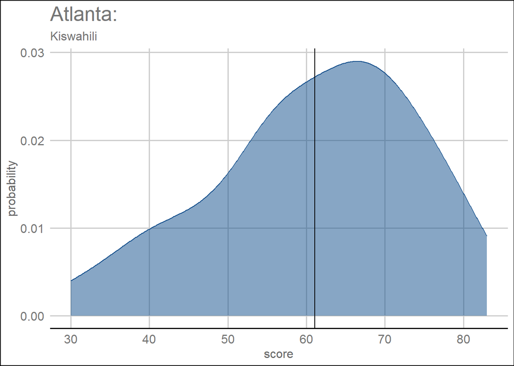

Atlanta’s Kiswahili scores have a kurtosis value of 2.57 and a skewness value of -0.48. This implies that the distribution is *platykurtic* and is *skewed negatively* about the mean.

## c. Mathematics

Here are the descriptive summaries of how students from Atlanta performed in Mathematics.

|  | 25% |
| --- | --- |
| **minimum** | 4 |
| **lower.q** | 33.5 |
| **Median** | 42 |
| **upper.q** | 54 |
| **maximum** | 88 |
| **average** | 44.7 |
| **standard.dev** | 18.13 |
| **c.o.v** | 40.57 |

### Distribution

The table below shows the percentage distribution of marks in Mathematics.

| 0-10 | 11-20 | 21-30 | 31-40 | 41-50 | 51-60 | 61-70 | 71-80 | 81-90 | 91-100 |
| --- | --- | --- | --- | --- | --- | --- | --- | --- | --- |
| 2 | 5 | 12 | 29 | 25 | 12 | 7 | 5 | 5 | 0 |

A majority of the students in Atlanta attained a score ranging from 31 to 40.

### Density function

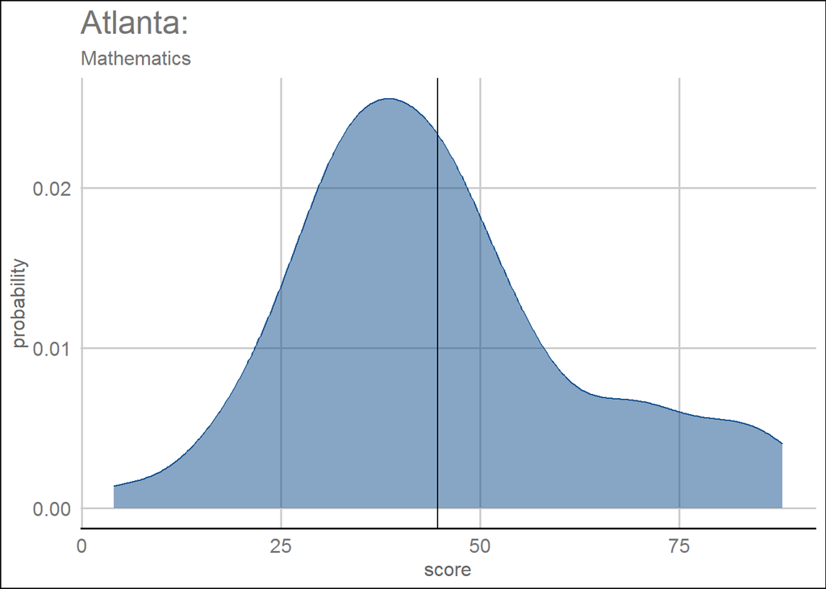

Atlanta’s Mathematics scores have a kurtosis value of 3.07 and a skewness value of 0.59. This implies that the distribution is *leptokurtic* and has a *mild skewness* about the mean.

## d. Science

Here are the descriptive summaries of how students from Atlanta performed in Science.

|  | 25% |
| --- | --- |
| **minimum** | 32 |
| **lower.q** | 50 |
| **Median** | 60 |
| **upper.q** | 70.5 |
| **maximum** | 92 |
| **average** | 60.6 |
| **standard.dev** | 14.34 |
| **c.o.v** | 23.66 |

### Distribution

The table below shows the percentage distribution of marks in Science.

| 0-10 | 11-20 | 21-30 | 31-40 | 41-50 | 51-60 | 61-70 | 71-80 | 81-90 | 91-100 |
| --- | --- | --- | --- | --- | --- | --- | --- | --- | --- |
| 0 | 0 | 0 | 9 | 19 | 29 | 20 | 17 | 7 | 2 |

A majority of the students in Atlanta attained a score ranging from 51 to 60.

### Density function

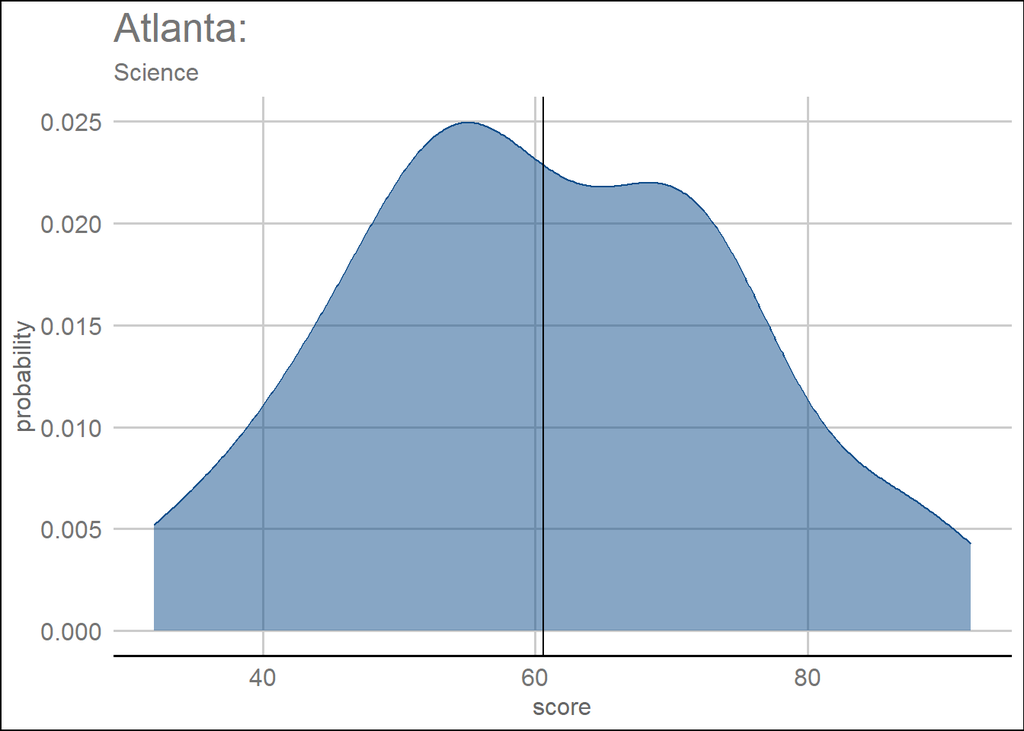

Atlanta’s Science scores have a kurtosis value of 2.45 and a skewness value of 0.08. This implies that the distribution is *platykurtic* and has a *mild skewness* about the mean.

## e. SSRE

Here are the descriptive summaries of how students from Atlanta performed in SSRE.

|  | 25% |
| --- | --- |
| **minimum** | 28 |
| **lower.q** | 59.5 |
| **Median** | 69.5 |
| **upper.q** | 76 |
| **maximum** | 91 |
| **average** | 66.9 |
| **standard.dev** | 13.1 |
| **c.o.v** | 19.58 |

### Distribution

The table below shows the percentage distribution of marks in SSRE.

| 0-10 | 11-20 | 21-30 | 31-40 | 41-50 | 51-60 | 61-70 | 71-80 | 81-90 | 91-100 |
| --- | --- | --- | --- | --- | --- | --- | --- | --- | --- |
| 0 | 0 | 2 | 2 | 5 | 20 | 25 | 34 | 12 | 2 |

A majority of the students in Atlanta attained a score ranging from 71 to 80.

### Density function

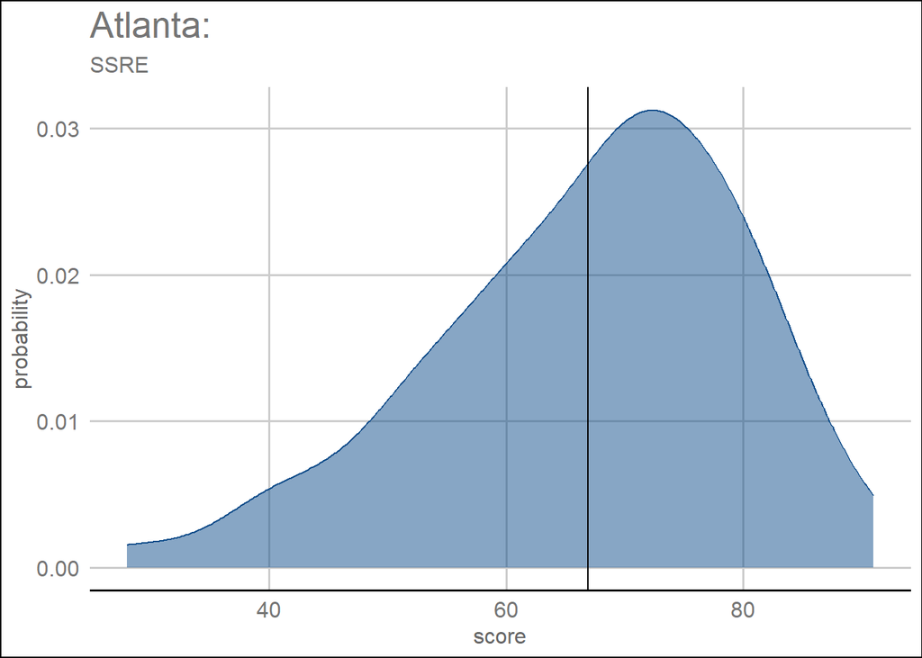

Atlanta’s SSRE scores have a kurtosis value of 3.2 and a skewness value of -0.69. This implies that the distribution is *leptokurtic* and has a *negative skewness* about the mean.

## f. Total

Here are the descriptive summaries of how students from Atlanta performed in all the subjects.

|  | 25% |
| --- | --- |
| **minimum** | 136 |
| **lower.q** | 243.5 |
| **Median** | 288 |
| **upper.q** | 329 |
| **maximum** | 411 |
| **average** | 286.7 |
| **standard.dev** | 64.13 |
| **c.o.v** | 22.37 |

### Distribution

The table below shows the percentage distribution of total marks in the Atlanta class.

| 0-100 | 101-200 | 201-300 | 301-400 | 401-500 |
| --- | --- | --- | --- | --- |
| 0 | 10 | 50 | 35 | 5 |

A majority of the students in Atlanta attained a total score ranging from 201 to 300.

### Density function

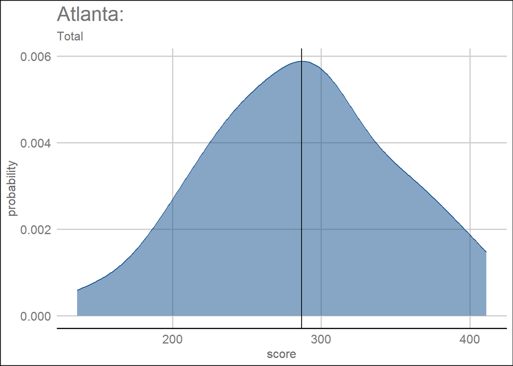

Atlanta’s total scores have a kurtosis value of 2.57 and a skewness value of -0.02. This implies that the distribution is *platykurtic* and has a *mild skewness* about the mean.

## a. English

Here are the descriptive summaries of how students from Indianna performed in English.

|  | 25% |
| --- | --- |
| **minimum** | 22 |
| **lower.q** | 46.75 |
| **Median** | 54.5 |
| **upper.q** | 61.75 |
| **maximum** | 84 |
| **average** | 53.67 |
| **standard.dev** | 12.51 |
| **c.o.v** | 23.31 |

### Distribution

The table below shows the percentage distribution of marks in English.

| 0-10 | 11-20 | 21-30 | 31-40 | 41-50 | 51-60 | 61-70 | 71-80 | 81-90 | 91-100 |
| --- | --- | --- | --- | --- | --- | --- | --- | --- | --- |
| 0 | 0 | 6 | 13 | 16 | 38 | 21 | 7 | 2 | 0 |

A majority of the students in Indianna attained a score ranging from 51 to 60.

### Density function

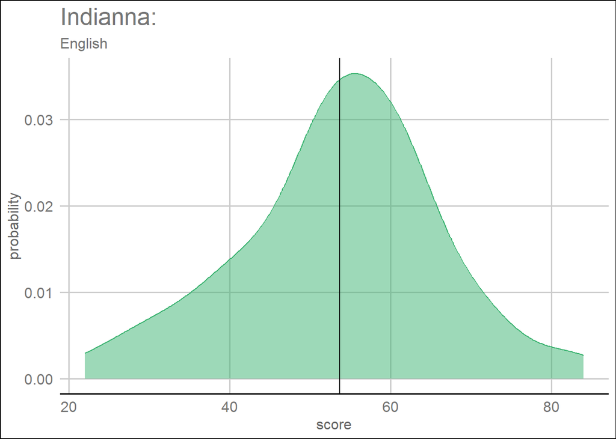

Indianna’s English scores have a kurtosis value of 3.2 and a skewness value of -0.22. This implies that the distribution is *leptokurtic* and is *mildly skewed* about the mean.

## b. Kiswahili

Here are the descriptive summaries of how students from Indianna performed in Kiswahili.

|  | 25% |
| --- | --- |
| **minimum** | 32 |
| **lower.q** | 52.75 |
| **Median** | 61 |
| **upper.q** | 67.75 |
| **maximum** | 79 |
| **average** | 59.78 |
| **standard.dev** | 11.67 |
| **c.o.v** | 19.52 |

### Distribution

The table below shows the percentage distribution of marks in Kiswahili.

| 0-10 | 11-20 | 21-30 | 31-40 | 41-50 | 51-60 | 61-70 | 71-80 | 81-90 | 91-100 |
| --- | --- | --- | --- | --- | --- | --- | --- | --- | --- |
| 0 | 0 | 0 | 9 | 9 | 32 | 37 | 16 | 0 | 0 |

A majority of the students in Indianna attained a score ranging from 61 to 70.

### Density function

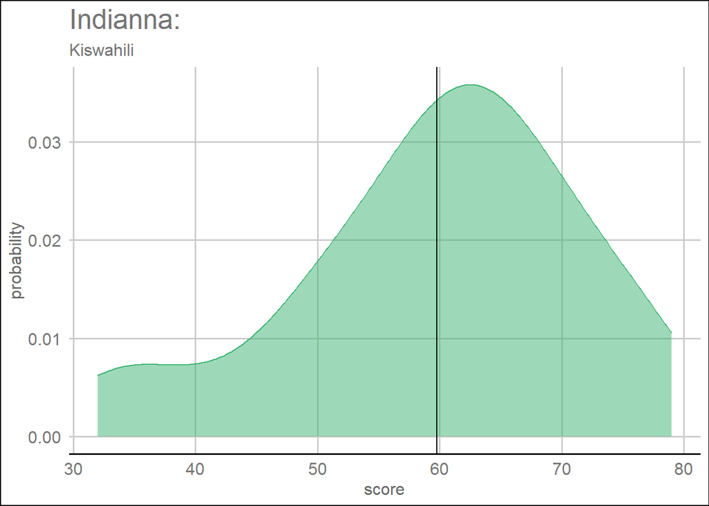

Indianna’s Kiswahili scores have a kurtosis value of 2.96 and a skewness value of -0.61. This implies that the distribution is *platykurtic* and is *moderately skewed* about the mean.

## c. Mathematics

Here are the descriptive summaries of how students from Indianna performed in Mathematics.

|  | 25% |
| --- | --- |
| **minimum** | 12 |
| **lower.q** | 32.5 |
| **Median** | 42 |
| **upper.q** | 61 |
| **maximum** | 86 |
| **average** | 45.9 |
| **standard.dev** | 17.51 |
| **c.o.v** | 38.15 |

### Distribution

The table below shows the percentage distribution of marks in Mathematics.

| 0-10 | 11-20 | 21-30 | 31-40 | 41-50 | 51-60 | 61-70 | 71-80 | 81-90 | 91-100 |
| --- | --- | --- | --- | --- | --- | --- | --- | --- | --- |
| 0 | 4 | 19 | 26 | 19 | 7 | 16 | 9 | 2 | 0 |

A majority of the students in Indianna attained a score ranging from 31 to 40.

### Density function

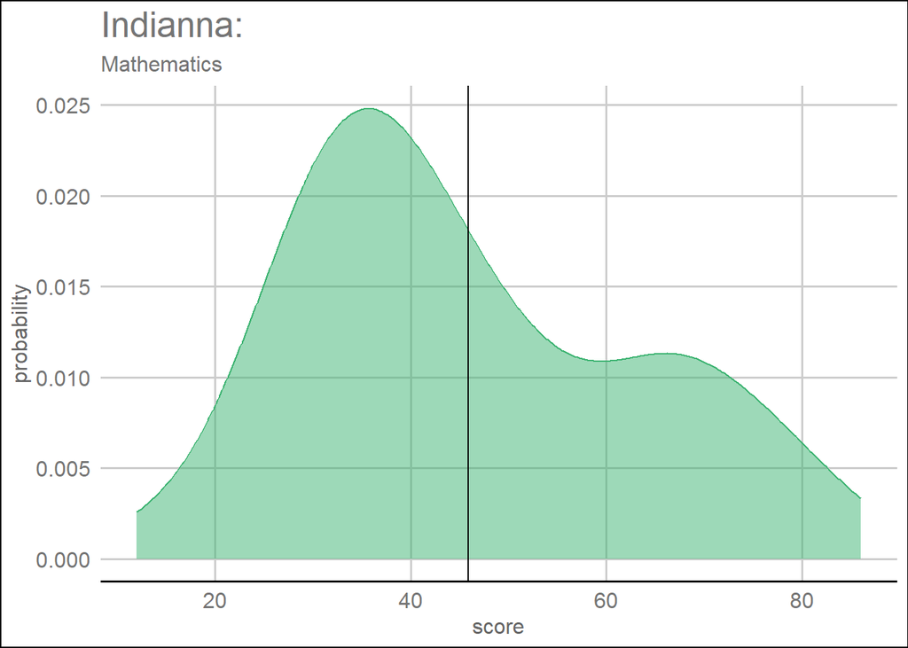

Indianna’s Mathematics scores have a kurtosis value of 2.3 and a skewness value of 0.51. This implies that the distribution is *platykurtic* and has a *moderate skewness* about the mean.

## d. Science

Here are the descriptive summaries of how students from Indianna performed in Science.

|  | 25% |
| --- | --- |
| **minimum** | 36 |
| **lower.q** | 50 |
| **Median** | 61 |
| **upper.q** | 73 |
| **maximum** | 94 |
| **average** | 61.62 |
| **standard.dev** | 16.26 |
| **c.o.v** | 26.39 |

### Distribution

The table below shows the percentage distribution of marks in Science.

| 0-10 | 11-20 | 21-30 | 31-40 | 41-50 | 51-60 | 61-70 | 71-80 | 81-90 | 91-100 |
| --- | --- | --- | --- | --- | --- | --- | --- | --- | --- |
| 0 | 0 | 0 | 16 | 14 | 21 | 25 | 11 | 13 | 4 |

A majority of the students in Indianna attained a score ranging from 61 to 70.

### Density function

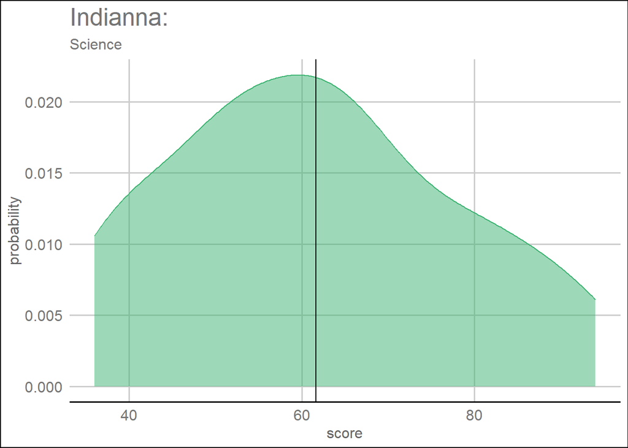

Indianna’s Science scores have a kurtosis value of 2.18 and a skewness value of 0.24. This implies that the distribution is *platykurtic* and has a *mild skewness* about the mean.

## e. SSRE

Here are the descriptive summaries of how students from Indianna performed in SSRE.

|  | 25% |
| --- | --- |
| **minimum** | 34 |
| **lower.q** | 57.5 |
| **Median** | 67 |
| **upper.q** | 78.25 |
| **maximum** | 92 |
| **average** | 66.59 |
| **standard.dev** | 13.96 |
| **c.o.v** | 20.97 |

### Distribution

The table below shows the percentage distribution of marks in SSRE.

| 0-10 | 11-20 | 21-30 | 31-40 | 41-50 | 51-60 | 61-70 | 71-80 | 81-90 | 91-100 |
| --- | --- | --- | --- | --- | --- | --- | --- | --- | --- |
| 0 | 0 | 0 | 7 | 7 | 16 | 32 | 21 | 16 | 4 |

A majority of the students in Indianna attained a score ranging from 61 to 70.

### Density function

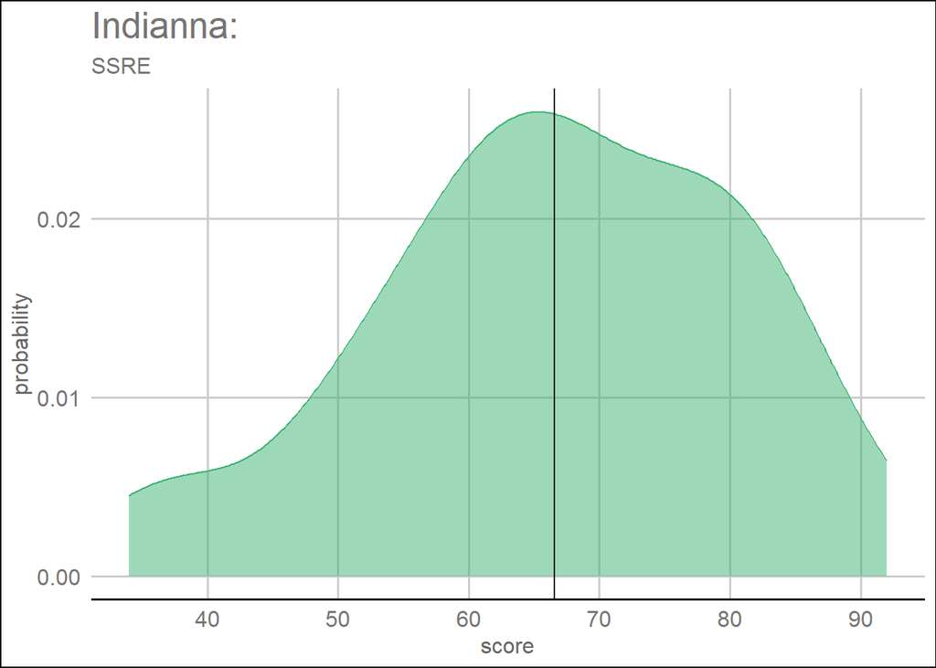

Indianna’s SSRE scores have a kurtosis value of 2.63 and a skewness value of -0.39. This implies that the distribution is *platykurtic* and has a *mild skewness* about the mean.

## f. Total

|  | 25% |
| --- | --- |
| **minimum** | 166 |
| **lower.q** | 243 |
| **Median** | 281 |
| **upper.q** | 328.5 |
| **maximum** | 422 |
| **average** | 287.6 |
| **standard.dev** | 63.11 |
| **c.o.v** | 21.95 |

### Distribution

[output not shown]

A majority of the students in Indianna attained a total score ranging from 201 to 300.

### Density function

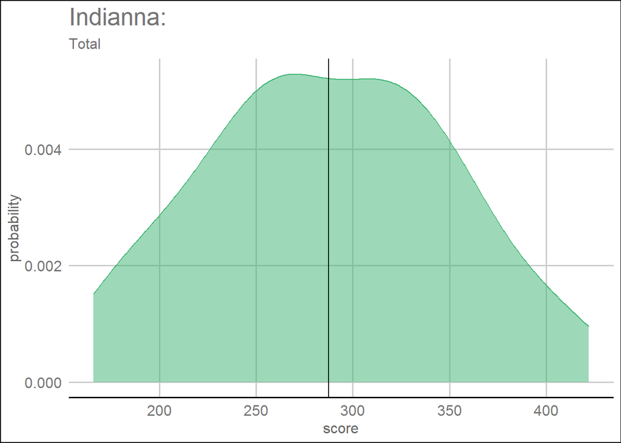

Indianna’s total scores have a kurtosis value of 2.3 and a skewness value of 0.03. This implies that the distribution is *platykurtic* and has a *mild skewness* about the mean.

## a. English

Here are the descriptive summaries of how students from Pacifica performed in English.

[output not shown]

### Distribution

The table below shows the percentage distribution of marks in English.

| 0-10 | 11-20 | 21-30 | 31-40 | 41-50 | 51-60 | 61-70 | 71-80 | 81-90 | 91-100 |
| --- | --- | --- | --- | --- | --- | --- | --- | --- | --- |
| 0 | 0 | 5 | 9 | 23 | 22 | 40 | 4 | 0 | 0 |

A majority of the students in Pacifica attained a score ranging from 61 to 70.

### Density function

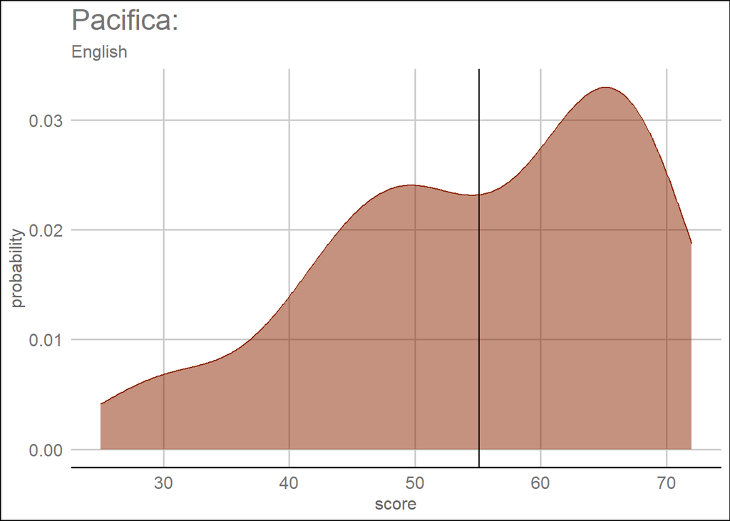

Pacifica’s English scores have a kurtosis value of 2.45 and a skewness value of -0.6. This implies that the distribution is *platykurtic* and is *moderately skewed* about the mean.

## b. Kiswahili

Here are the descriptive summaries of how students from Pacifica performed in Kiswahili.

|  | 25% |
| --- | --- |
| **minimum** | 38 |
| **lower.q** | 53 |
| **Median** | 63 |
| **upper.q** | 68 |
| **maximum** | 78 |
| **average** | 61.16 |
| **standard.dev** | 10.32 |
| **c.o.v** | 16.87 |

### Distribution

The table below shows the percentage distribution of marks in Kiswahili.

| 0-10 | 11-20 | 21-30 | 31-40 | 41-50 | 51-60 | 61-70 | 71-80 | 81-90 | 91-100 |
| --- | --- | --- | --- | --- | --- | --- | --- | --- | --- |
| 0 | 0 | 0 | 2 | 22 | 14 | 43 | 22 | 0 | 0 |

### Density function

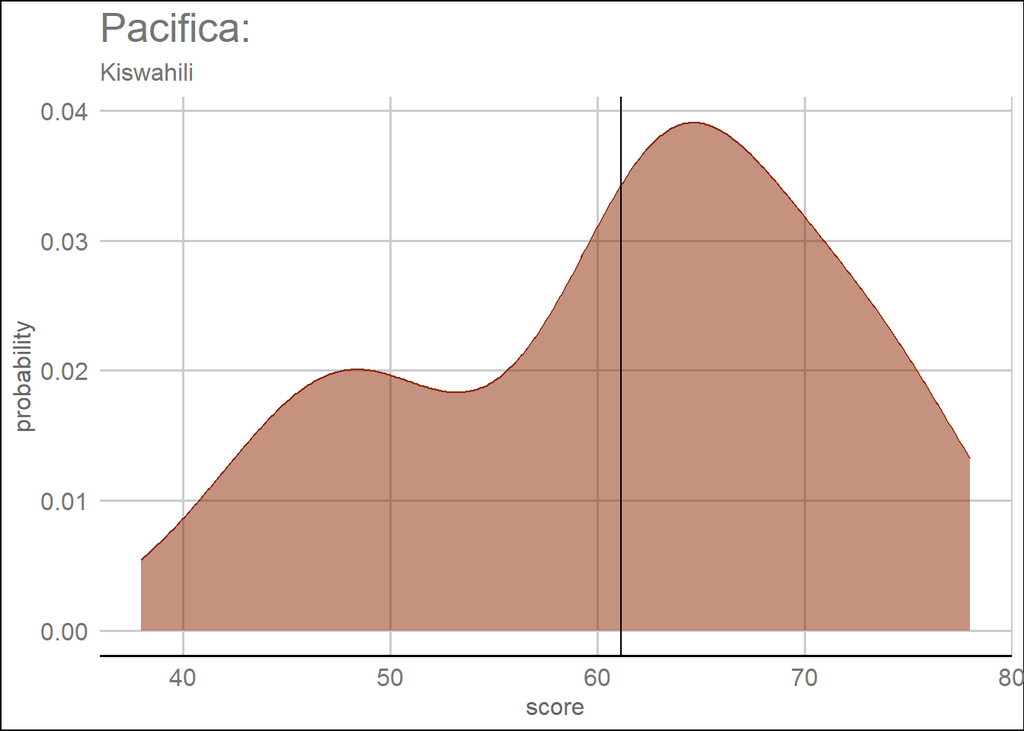

Pacifica’s Kiswahili scores have a kurtosis value of 2.19 and a skewness value of -0.39. This implies that the distribution is *platykurtic* and is *mildly skewed* about the mean.

## c. Mathematics

Here are the descriptive summaries of how students from Pacifica performed in Mathematics.

|  | 25% |
| --- | --- |
| **minimum** | 22 |
| **lower.q** | 34 |
| **Median** | 44 |
| **upper.q** | 54 |
| **maximum** | 90 |
| **average** | 47.11 |
| **standard.dev** | 17.42 |
| **c.o.v** | 36.98 |

### Distribution

The table below shows the percentage distribution of marks in Mathematics.

[output not shown]

A majority of the students in Pacifica attained a score ranging from 31 to 40.

### Density function

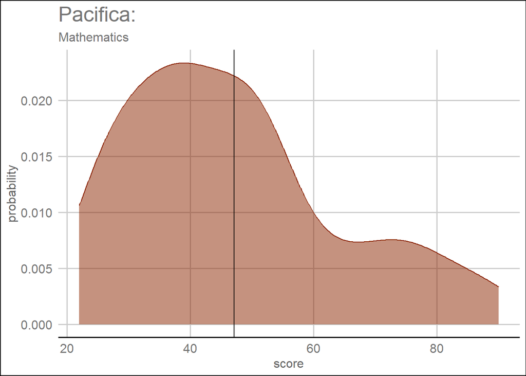

Pacifica’s Mathematics scores have a kurtosis value of 2.77 and a skewness value of 0.74. This implies that the distribution is *platykurtic* and has a *moderate skewness* about the mean.

## d. Science

Here are the descriptive summaries of how students from Pacifica performed in Science.

|  | 25% |
| --- | --- |
| **minimum** | 28 |
| **lower.q** | 50 |
| **Median** | 58 |
| **upper.q** | 72 |
| **maximum** | 92 |
| **average** | 60.23 |
| **standard.dev** | 16.3 |
| **c.o.v** | 27.06 |

### Distribution

The table below shows the percentage distribution of marks in Science.

| 0-10 | 11-20 | 21-30 | 31-40 | 41-50 | 51-60 | 61-70 | 71-80 | 81-90 | 91-100 |
| --- | --- | --- | --- | --- | --- | --- | --- | --- | --- |
| 0 | 0 | 4 | 10 | 15 | 27 | 20 | 12 | 14 | 2 |

A majority of the students in Pacifica attained a score ranging from 51 to 60 .

### Density function

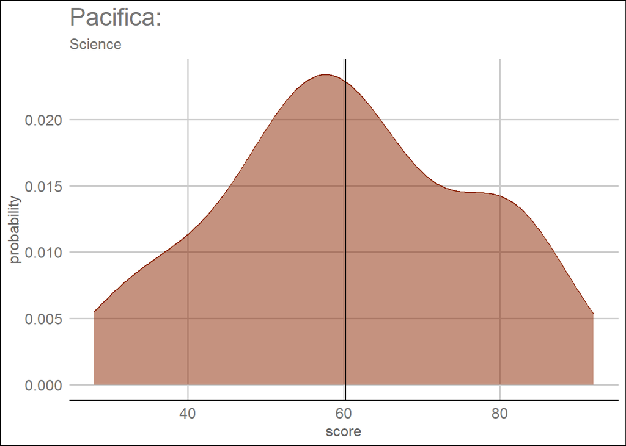

Pacifica’s Science scores have a kurtosis value of 2.25 and a skewness value of -0.03. This implies that the distribution is *platykurtic* and has a *mild skewness* about the mean.

## e. SSRE

Here are the descriptive summaries of how students from Pacifica performed in SSRE.

|  | 25% |
| --- | --- |
| **minimum** | 40 |
| **lower.q** | 60 |
| **Median** | 67 |
| **upper.q** | 77 |
| **maximum** | 87 |
| **average** | 66.98 |
| **standard.dev** | 12.06 |
| **c.o.v** | 18.01 |

### Distribution

The table below shows the percentage distribution of marks in SSRE.

| 0-10 | 11-20 | 21-30 | 31-40 | 41-50 | 51-60 | 61-70 | 71-80 | 81-90 | 91-100 |
| --- | --- | --- | --- | --- | --- | --- | --- | --- | --- |
| 0 | 0 | 0 | 2 | 10 | 22 | 30 | 22 | 17 | 0 |

A majority of the students in Pacifica attained a score ranging from 61 to 70.

### Density function

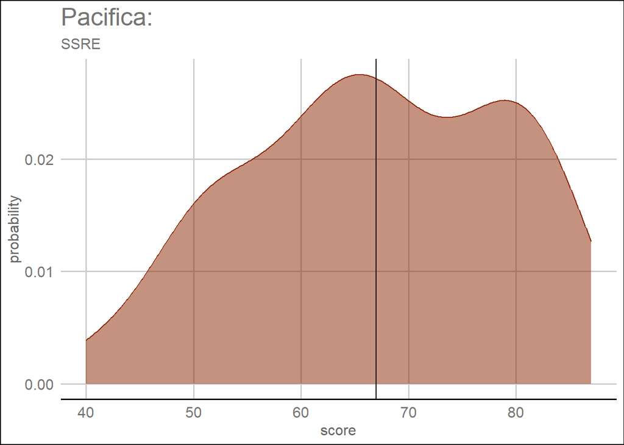

Pacifica’s SSRE scores have a kurtosis value of 2.06 and a skewness value of -0.22. This implies that the distribution is *platykurtic* and has a *mild skewness* about the mean.

## f. Total

Here are the descriptive summaries of how students from Pacifica performed in all the subjects

|  | 25% |
| --- | --- |
| **minimum** | 163 |
| **lower.q** | 249 |
| **Median** | 296 |
| **upper.q** | 332 |
| **maximum** | 414 |
| **average** | 290.6 |
| **standard.dev** | 61.04 |
| **c.o.v** | 21.01 |

### Distribution

The table below shows the percentage distribution of total marks in the Pacifica class.

| 0-100 | 101-200 | 201-300 | 301-400 | 401-500 |
| --- | --- | --- | --- | --- |
| 0 | 9 | 46 | 45 | 2 |

A majority of the students in Pacifica attained a total score ranging from 201 to 300.

### Density function

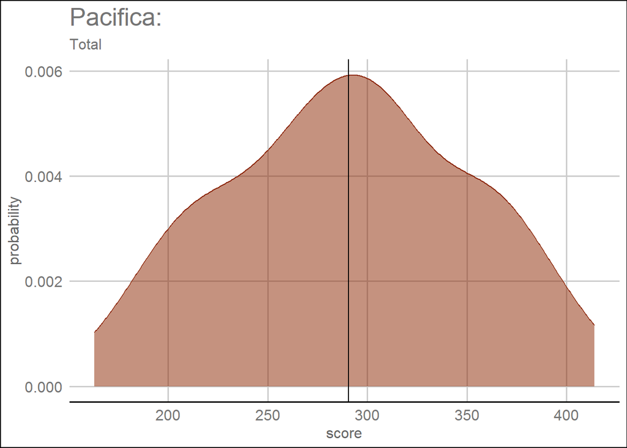

Pacifica’s total scores have a kurtosis value of 2.2 and a skewness value of -0.03. This implies that the distribution is *platykurtic* and has a *mild skewness* about the mean.

# 3. Combined performance

## A. English

Here are the descriptive summaries of how all the students performed in English.

|  | 25% |
| --- | --- |
| **minimum** | 8 |
| **lower.q** | 45.5 |
| **Median** | 55 |
| **upper.q** | 64 |
| **maximum** | 84 |
| **average** | 54.08 |
| **standard.dev** | 13 |
| **c.o.v** | 24.04 |

### Distribution

The table below shows the percentage distribution of marks in English.

| 0-10 | 11-20 | 21-30 | 31-40 | 41-50 | 51-60 | 61-70 | 71-80 | 81-90 | 91-100 |
| --- | --- | --- | --- | --- | --- | --- | --- | --- | --- |
| 1 | 0 | 5 | 12 | 21 | 28 | 28 | 8 | 1 | 0 |

A majority of the students attained a score ranging from 51 to 70.

### Density function

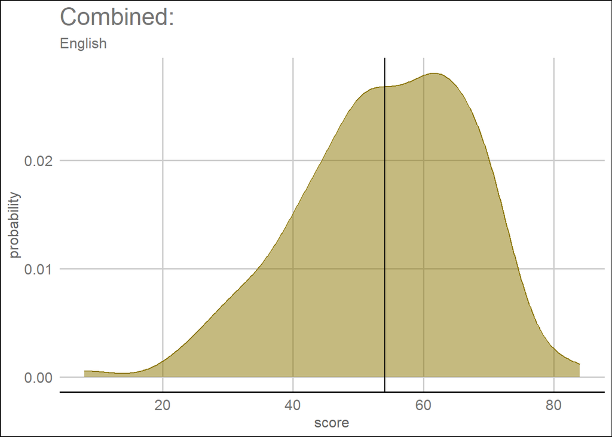

The combined English scores have a kurtosis value of 3.08 and a skewness value of -0.51. This implies that the distribution is *leptokurtic* and is *moderately skewed* about the mean.

## B. Kiswahili

Here are the descriptive summaries of how all the students performed in Kiswahili.

|  | 25% |
| --- | --- |
| **minimum** | 30 |
| **lower.q** | 53 |
| **Median** | 63 |
| **upper.q** | 69.5 |
| **maximum** | 83 |
| **average** | 60.68 |
| **standard.dev** | 11.67 |
| **c.o.v** | 19.23 |

### Distribution

The table below shows the percentage distribution of marks in Kiswahili.

| 0-10 | 11-20 | 21-30 | 31-40 | 41-50 | 51-60 | 61-70 | 71-80 | 81-90 | 91-100 |
| --- | --- | --- | --- | --- | --- | --- | --- | --- | --- |
| 0 | 0 | 1 | 7 | 14 | 23 | 37 | 19 | 2 | 0 |

A majority of the students attained a score ranging from 61 to 70.

### Density function

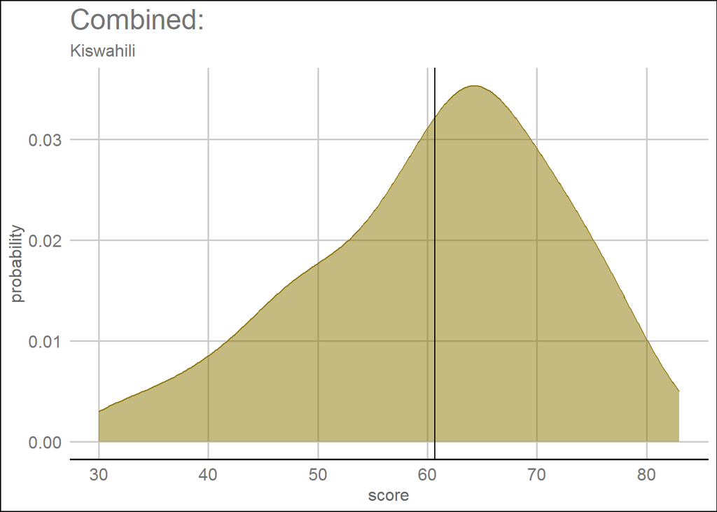

The combined Kiswahili scores have a kurtosis value of 2.73 and a skewness value of -0.51. This implies that the distribution is *platykurtic* and is *moderately skewed* about the mean.

## C. Mathematics

Here are the descriptive summaries of how all the students performed in Mathematics.

|  | 25% |
| --- | --- |
| **minimum** | 4 |
| **lower.q** | 34 |
| **Median** | 42 |
| **upper.q** | 54 |
| **maximum** | 90 |
| **average** | 45.91 |
| **standard.dev** | 17.62 |
| **c.o.v** | 38.38 |

### Distribution

The table below shows the percentage distribution of marks in Mathematics.

| 0-10 | 11-20 | 21-30 | 31-40 | 41-50 | 51-60 | 61-70 | 71-80 | 81-90 | 91-100 |
| --- | --- | --- | --- | --- | --- | --- | --- | --- | --- |
| 1 | 3 | 17 | 27 | 22 | 11 | 10 | 8 | 4 | 0 |

A majority of the students attained a score ranging from 31 to 40.

### Density function

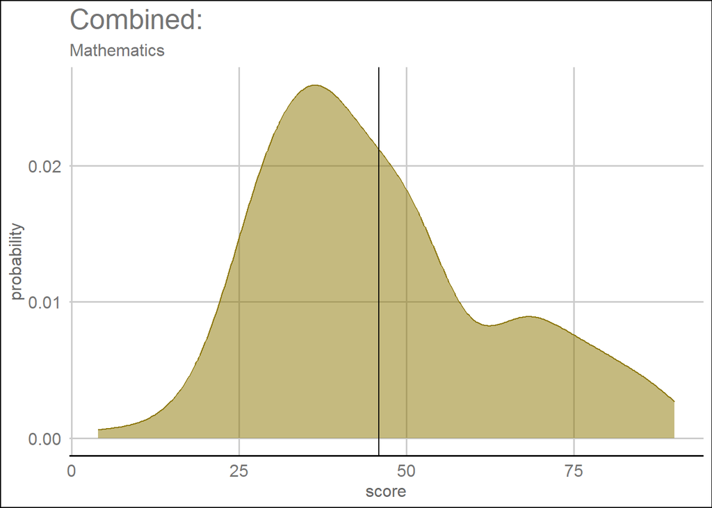

The combined Mathematics scores have a kurtosis value of 2.75 and a skewness value of 0.6. This implies that the distribution is *platykurtic* and is *moderately skewed* about the mean.

## D. Science

Here are the descriptive summaries of how all the students performed in Science.

|  | 25% |
| --- | --- |
| **minimum** | 28 |
| **lower.q** | 50 |
| **Median** | 60 |
| **upper.q** | 72 |
| **maximum** | 94 |
| **average** | 60.8 |
| **standard.dev** | 15.58 |
| **c.o.v** | 25.62 |

### Distribution

The table below shows the percentage distribution of marks in Science.

| 0-10 | 11-20 | 21-30 | 31-40 | 41-50 | 51-60 | 61-70 | 71-80 | 81-90 | 91-100 |
| --- | --- | --- | --- | --- | --- | --- | --- | --- | --- |
| 0 | 0 | 2 | 12 | 16 | 26 | 22 | 13 | 11 | 3 |

A majority of the students attained a score ranging from 51 to 60.

### Density function

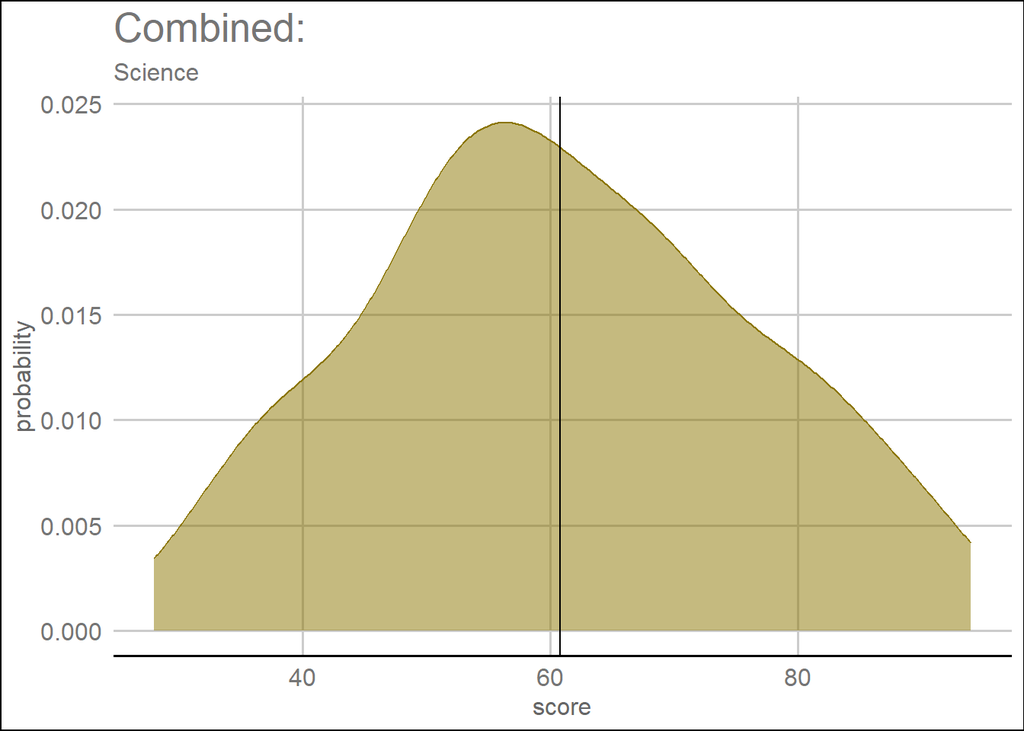

The combined Science scores have a kurtosis value of 2.32 and a skewness value of 0.1. This implies that the distribution is *platykurtic* and is *mildly skewed* about the mean.

## E. SSRE

Here are the descriptive summaries of how all the students performed in SSRE.

|  | 25% |
| --- | --- |
| **minimum** | 28 |
| **lower.q** | 58.5 |
| **Median** | 68 |
| **upper.q** | 77 |
| **maximum** | 92 |
| **average** | 66.83 |
| **standard.dev** | 12.98 |
| **c.o.v** | 19.42 |

### Distribution

The table below shows the percentage distribution of marks in SSRE.

| 0-10 | 11-20 | 21-30 | 31-40 | 41-50 | 51-60 | 61-70 | 71-80 | 81-90 | 91-100 |
| --- | --- | --- | --- | --- | --- | --- | --- | --- | --- |
| 0 | 0 | 1 | 4 | 8 | 19 | 29 | 26 | 15 | 2 |

A majority of the students attained a score ranging from 61 to 70.

### Density function

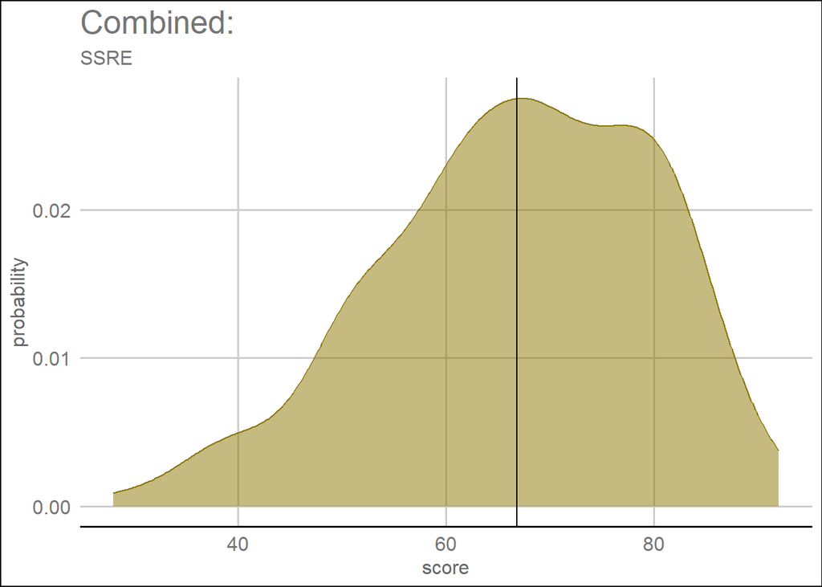

The combined SSRE scores have a kurtosis value of 2.72 and a skewness value of -0.45. This implies that the distribution is *platykurtic* and is *mildly skewed* about the mean.

## F. Total

Here are the descriptive summaries of how all the students in Ebulako Primary School performed in the 2023 Ivy League exam.

|  | 25% |
| --- | --- |
| **minimum** | 136 |
| **lower.q** | 244.5 |
| **Median** | 290 |
| **upper.q** | 330.5 |
| **maximum** | 422 |
| **average** | 288.3 |
| **standard.dev** | 62.43 |
| **c.o.v** | 21.65 |

### Distribution

The table below shows the percentage distribution of the total marks.

| 0-100 | 101-200 | 201-300 | 301-400 | 401-500 |
| --- | --- | --- | --- | --- |
| 0 | 10 | 47 | 41 | 4 |

A majority of the students attained a score ranging from 201 to 300.

### Density function

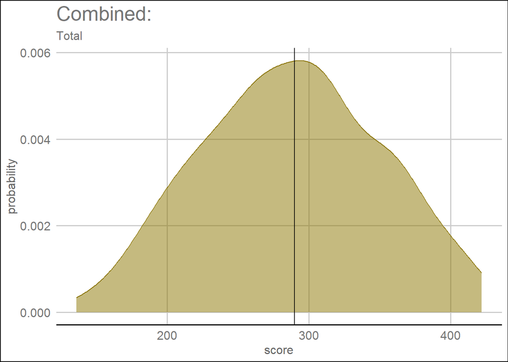

The combined total scores have a kurtosis value of 2.37 and a skewness value of -0.01. This implies that the distribution is *platykurtic* and is *mildly skewed* about the mean.

# 4. Best students

The students who achieved the highest marks per subject are highlighted below.

## English

| english | kiswahili | math | science | SSRE | stream | total |
| --- | --- | --- | --- | --- | --- | --- |
| 84 | 72 | 86 | 94 | 86 | I | 422 |

## Kiswahili

|  | english | kiswahili | math | science | SSRE | stream | total |
| --- | --- | --- | --- | --- | --- | --- | --- |
| **5** | 71 | 83 | 84 | 92 | 81 | A | 411 |

## Mathematics

|  | english | kiswahili | math | science | SSRE | stream | total |
| --- | --- | --- | --- | --- | --- | --- | --- |
| **9** | 66 | 76 | 90 | 80 | 83 | P | 395 |

## Science

|  | english | kiswahili | math | science | SSRE | stream | total |
| --- | --- | --- | --- | --- | --- | --- | --- |
| **1** | 84 | 72 | 86 | 94 | 86 | I | 422 |
| **10** | 72 | 65 | 78 | 94 | 82 | I | 391 |

## SSRE

|  | english | kiswahili | math | science | SSRE | stream | total |
| --- | --- | --- | --- | --- | --- | --- | --- |
| **6** | 72 | 74 | 80 | 90 | 92 | I | 408 |

## Total

| english | kiswahili | math | science | SSRE | stream | total |
| --- | --- | --- | --- | --- | --- | --- |
| 84 | 72 | 86 | 94 | 86 | I | 422 |

# 5. Subject performance per class

## A. English

### a. Average

The mean scores for English from the 3 classes are shown below.

| stream | subject.mean |
| --- | --- |
| P | 55.08 |
| I | 53.67 |
| A | 53.45 |

Leading in English is Pacifica with a mean score of 55.08, followed by Indianna then Atlanta.

### b. Deviation

| stream | subject.sd |
| --- | --- |
| A | 14.38 |
| I | 12.51 |
| P | 12.16 |

Atlanta recorded the highest deviation in English with 14.38 marks.

## B. Kiswahili

### a. Average

The mean scores for Kiswahili from the 3 classes are shown below.

| stream | subject.mean |
| --- | --- |
| P | 61.16 |
| A | 61.07 |
| I | 59.78 |

Leading in Kiswahili is Pacifica with a mean score of 61.16, followed by Atlanta then Indianna.

### b. Deviation

| stream | subject.sd |
| --- | --- |
| A | 13.03 |
| I | 11.67 |
| P | 10.32 |

Atlanta recorded the highest deviation in Kiswahili with 13.03 marks.

## C. Mathematics

### a.Average

The mean scores for Mathematics from the 3 classes are shown below.

| stream | subject.mean |
| --- | --- |
| P | 47.11 |
| I | 45.9 |
| A | 44.7 |

In Mathematics, Pacifica leads with a mean score of 47.11, followed by Indianna then Atlanta.

### b. Deviation

| stream | subject.sd |
| --- | --- |
| A | 18.13 |
| I | 17.51 |
| P | 17.42 |

Atlanta recorded the highest deviation in Mathematics with 18.13 marks.

## D. Science

### a. Average

The mean scores for Science from the 3 classes are shown below.

| stream | subject.mean |
| --- | --- |
| I | 61.62 |
| A | 60.6 |
| P | 60.23 |

Leading in Science is Indianna with a mean score of 61.62, followed by Atlanta then Pacifica.

### b. Deviation

| stream | subject.sd |
| --- | --- |
| P | 16.3 |
| I | 16.26 |
| A | 14.34 |

Pacifica recorded the highest deviation in Science with 16.3 marks.

## E. SSRE

### a. Average

The mean scores for SSRE from the 3 classes are shown below.

| stream | subject.mean |
| --- | --- |
| P | 66.98 |
| A | 66.9 |
| I | 66.59 |

### b. Deviation

| stream | subject.sd |
| --- | --- |
| I | 13.96 |
| A | 13.1 |
| P | 12.06 |

Indianna recorded the highest deviation in SSRE with 13.96 marks.

## F. Total

### a. Average

The overall mean scores for all the 3 classes are shown below.

| stream | subject.mean |
| --- | --- |
| P | 290.6 |
| I | 287.6 |
| A | 286.7 |

Overally, Pacifica leads with an average score of 290.6 followed by Indianna then Atlanta.

### b. Deviation

| stream | subject.sd |
| --- | --- |
| A | 64.13 |
| I | 63.11 |
| P | 61.04 |

Atlanta recorded the highest overall score deviation with 64.13 marks.